# SU_25_River_Rockfish_Proj_Graphs

River Mckegney

2025-07-21

## Setup, and Packages

Code Packages:

```r
# Load packages
library(gridExtra) # For using grid.table to save tables as images
library(flextable) # Alternative method to save df as image
library(tidyverse)
library(zoo)
library(lme4)
library(lmerTest)
library(rlang)
library(nortest) # For ad.test
library(car) # For homogeneity of variance with leveneTest
library(rcompanion) # For scheirerRayHare test
library(pastecs) # For stat.desc
library(ggpubr) # For assumption plots
library(conover.test) # For the conover.Iman() test function
library(DescTools) # Contain alternative ConoverTest function
library(rstatix) # tidyverse adapted stat tests and mshapiro_test() functions
library(DHARMa) # For multi-level lm models and shapiro test
library(patchwork) # For combining ggplots
```

## Data Entry: Read-in data

```r
# Read and call data into df

# Primary samples df
ABL90 <- read.csv("Raw_Data/ABL90_Raw.csv")

# River's Parturition metadata
partuition_subcat <- read.csv("Raw_Data/River's_Rockfish_Metadata_Parturition_V7.csv")
```

## Data Filtering

```r
# Data sifting: ABL90 dataset

# Step 1: Remove missing info
ABL_set1 <- ABL90 %>%
  filter(Patient.ID_edited != "")


# Step 2: Separate Patient.ID into columns of sample types: blood plasma and instant freeze plasma
ABL_set2 <- separate(ABL_set1, 'Patient.ID_edited', into = c("Patient.ID_edited", "Sample_Type"), sep = ",")
# Step 3:
# Convert Patient.ID_edited column data to character type
ABL_set2$Patient.ID_edited <- as.character(ABL_set2$Patient.ID_edited)
```

```r
# Step 4 & 5: Sussing out specific sample errors

# Remove insufficient samples
ABL_set3 <- ABL_set2 %>%
  filter(!is.na("Type")) %>%
  filter(!str_detect(Errors.detected.during.measurement, "Insufficient sample"))

# Remove inhomogeneous samples
ABL_set3 <- ABL_set3 %>%
  filter(!is.na("Type")) %>%
  filter(!str_detect(Errors.detected.during.measurement, "Inhomogeneous sample"))

# Step 6: Filter for only blood samples
ABL_b_samp <- ABL_set3 %>%
  filter(Sample_Type == "b")
```

## Merge Datasets:

Join ABL90 df with parturition_subcat df: Making ABL_merged

```r
# Rename columns to match: Change 'ID' in parturition_subcat to 'Patient.ID_edited' so it is ready to join with ABL90 df

# Please note the 'Treatment' col in parturition_subcat does not match with the finalized 'Ambient.Or.OAH' col in metadata_atresia_guide or ABL90_merged df

# Rename 'ID' col to 'patient.ID_edited'
partuition_subcat <- partuition_subcat %>%
  rename(Patient.ID_edited = ID)
```

```r
# Connect main ABL90 dataset with my (River's) sub categorized parturition metadata
# ABL_merged <- partuition_subcat %>%
# left_join(ABL_b_samp, by = "Patient.ID_edited")

ABL_merged <- ABL_b_samp %>%
inner_join(partuition_subcat, by = "Patient.ID_edited")
```

Rename Columns Neatly:

```r
# Rename Treatment & Parturition Outcome
ABL_merged <- ABL_merged %>%
  rename(Ambient.Or.OAH = Consensus_General_Treatment,
         Pregnant.Or.Atresia = Consensus_Atresia_Or_Pregnant)
```

## Remove Samples: Mortalities, NA’s, or Missing Info, and Replicates

Remove Replicate ID’s

```r
# Cross Check all Columns: Cross validation to suss correct replicate row
check_params <- ABL_merged %>%
  select(Patient.ID_edited, Time, Sample.., Measuring.Mode, Ambient.Or.OAH, Pregnant.Or.Atresia, pH, Glu..mmol.L., Hct...., Na...mmol.L., Cl...mmol.L., K...mmol.L., Ca....mmol.L., pCO2..mmHg.) %>%
  filter(Patient.ID_edited == "9782D")
print(check_params)
```

```
##   Patient.ID_edited             Time Sample.. Measuring.Mode Ambient.Or.OAH
## 1             9782D 12/28/2023 10:04     1016         C 65uL        Ambient
## 2             9782D   1/9/2024 17:21      863         S 65uL        Ambient
##   Pregnant.Or.Atresia    pH Glu..mmol.L. Hct.... Na...mmol.L. Cl...mmol.L.
## 1    Post Parturition 7.348          0.5     9.8          184          149
## 2    Post Parturition 7.446          0.7    13.3          181          161
##   K...mmol.L. Ca....mmol.L. pCO2..mmHg.
## 1         2.8          1.32         4.2
## 2         2.9          1.31         6.8
```

```r
check_params <- ABL_merged %>%
  select(Patient.ID_edited, Time, Sample.., Measuring.Mode, Ambient.Or.OAH, Pregnant.Or.Atresia, pH, Glu..mmol.L., Hct...., Na...mmol.L., Cl...mmol.L., K...mmol.L., Ca....mmol.L., pCO2..mmHg.) %>%
  filter(Patient.ID_edited == "9783D")
print(check_params)
```

```
##   Patient.ID_edited            Time Sample.. Measuring.Mode Ambient.Or.OAH
## 1             9783D 1/19/2024 10:37      934         S 65uL        Ambient
## 2             9783D  1/7/2024 12:32      860         S 65uL        Ambient
##   Pregnant.Or.Atresia    pH Glu..mmol.L. Hct.... Na...mmol.L. Cl...mmol.L.
## 1    Post Parturition 7.484          1.7     0.2          175          193
## 2    Post Parturition 7.450          1.3    14.7          179          164
##   K...mmol.L. Ca....mmol.L. pCO2..mmHg.
## 1        34.5          1.29         8.5
## 2         2.5          1.30         5.3
```

```r
# Removed replicates: 9782D (2x) and 9783D (2x)
ABL_merged <- ABL_merged %>%
  filter(Sample.. != "863",
         Sample.. != "934")
```

Review Replicates:

| Row | ID | Time | Sample.. | Measuring.Mode | pH | Glu.mmol.L. | Hct…. | Na…mmol.L. | Cl…mmol.L. | K…mmol.L. | Ca.mmol.L. |
| --- | --- | --- | --- | --- | --- | --- | --- | --- | --- | --- | --- |
| 32 | 9782D | 12/28/2023 10:04 | 1016 | C 65uL | 7.348 | 0.5 | 9.8 | 184 | 149 | 2.8 | 1.32 |
| 39 | 9782D | 1/9/2024 17:21 | 863 | S 65uL | 7.446 | 0.7 | 13.3 | 181 | 161 | 2.9 | 1.31 |
| 36 | 9783D | 1/19/2024 10:37 | 934 | S 65uL | 7.484 | 1.7 | **0.2** | 175 | 193 | **34.5** | 1.29 |
| 41 | 9783D | 1/7/2024 12:32 | 860 | S 65uL | 7.450 | 1.3 | **14.7** | 179 | 164 | **2.5** | 1.30 |

Methods for replicate sample removal: Check processing date of IDs, and remove samples that do not match that date.

Case ID_9782D:

- Origianl ABL90 set contains:
- 9782D,b (Sample.. 1016, Time = 12/28/2023 10:04:00 AM)
- 9782D,p (Sample.. 1020, Time = 12/28/2023 10:25:00 AM)
- 9782D,p (Sample.. 865, Time = 1/9/2024 5:29:00 PM)
- 9782D,b (Sample.. 863, Time = 1/9/2024 5:21:00 PM)
- 2024_Fish_Metadata.csv says ID_9782D was processed 3/29/2024
- Note Processing date in metadata will not match time date stamp in ABL90 data due to the machine being reset, and innacurrate dates being automatically recorded.

Deciding info: - For ID-9782D, refer to metadata sheet and look for other samples with that same processing date, then view thoes samples ABL90 ‘Time’. Try to find a matching ‘Time’ with other IDs and 9782D that were processed together during the same time recorded by the machine.

Case ID_9783D

- Original ABL90 dataset contains:
- 9783D,b (Sample.. 934, Time = 1/19/2024 10:37:00 AM)
- 9783D,c (Sample.. 861, Time = 1/7/2024 12:38:00 PM)
- 9783D,b (Sample.. 860, Time = 1/7/2024 12:32:00 PM)
- 2024_Fish_Metadata.csv says ID_9783D was processed 3/20/2024
- Informed that ID_9783D: Sample.. 934 is a plasma sample (on account of its low hct value), remove this and **keep Sample.. 860 (parameter values appear correct)**.

# Samples: Data subsets

Remove Mortalities and No info IDs and assign analysis ready data-frames:

```r
# New df with Moralities removed: Note none of these samples made it into ABL90 df anyway, so looks like they are already filtered out.
 Live_Samples <- ABL_merged %>%
  filter(Patient.ID_edited != "9780C", # Mortality
         Patient.ID_edited != "777AE", # Mortality
         Patient.ID_edited != "777CA") # Mortality after parturition


# New df with mortality and 'No info' Id's removed
 Primary_Samples <- Live_Samples %>%
   filter(Patient.ID_edited != "777A0", # No info
           Patient.ID_edited != "9782F", # No info
           Patient.ID_edited != "777B3", # No info
           Patient.ID_edited != "777AA", # No info
           Patient.ID_edited != "777DE", # No info
           Patient.ID_edited != "777CE", # No info
           Patient.ID_edited != "777A6") # No info


# New df of Only Ambient Treatment: For testing parturition success
 Ambient_Samples <- Primary_Samples %>%
   filter(Ambient.Or.OAH == "Ambient")

# New df of Fecundity Samples: For Background Correlative Evidence To Compare with Brood Condition Categorization
 Fecundity_Samples <- Primary_Samples %>%
   filter(Fecundity_Or_Brood_Count != "NA",
     Fecundity_Class != "NA") # removes 97706

# Fecundity samples used for deciphering correlations with continuous brood count data
 Fecundity_Count_Samples <- Primary_Samples %>%
   filter(All_Fecundity != "NA") # removes 97706

# Fecundity Ambient Samples
 Amb_Fec_Samples <- Primary_Samples %>%
   filter(Ambient.Or.OAH == "Ambient",
          All_Fecundity != "NA") # removes OAH treatment samples and ID 97706
```

Change Data Types:

```r
# Change Continuous Data to type to numeric, double, or factor

# Change data type of ions to factor or numeric
#glimpse(General_Samples)
#glimpse(Ambient_Samples)

Primary_Samples <- Primary_Samples %>%
  mutate(across(c(All_Fecundity, pH, Hct...., Glu..mmol.L., Na...mmol.L., Cl...mmol.L., K...mmol.L., Ca....mmol.L.), as.numeric))

Ambient_Samples <- Ambient_Samples %>%
  mutate(across(c(All_Fecundity, pH, Hct...., Glu..mmol.L., Na...mmol.L., Cl...mmol.L., K...mmol.L., Ca....mmol.L.), as.numeric))

Fecundity_Samples <- Fecundity_Samples %>%
  mutate(across(c(All_Fecundity, pH, Hct...., Glu..mmol.L., Na...mmol.L., Cl...mmol.L., K...mmol.L., Ca....mmol.L.), as.numeric))

Fecundity_Count_Samples <- Fecundity_Samples %>%
  mutate(across(c(All_Fecundity, pH, Hct...., Glu..mmol.L., Na...mmol.L., Cl...mmol.L., K...mmol.L., Ca....mmol.L.), as.numeric))

Amb_Fec_Samples <- Amb_Fec_Samples %>%
  mutate(across(c(All_Fecundity, pH, Hct...., Glu..mmol.L., Na...mmol.L., Cl...mmol.L., K...mmol.L., Ca....mmol.L.), as.numeric))


# glimpse(Primary_Samples)
# glimpse(Ambient_Samples)
# glimpse(Fecundity_Samples)
# glimpse(Fecundity_Count_Samples)
# glimpse(Amb_Fec_Samples)
```

## Order Factor Levels

```r
# Fecundity data

#unique(Fecundity_Samples$Fecundity_Class)

# Arrange the order of parturition categories for visualizations & tests

# Primary Samples
Primary_Samples$Ambient.Or.OAH <- ordered(Primary_Samples$Ambient.Or.OAH, levels = c("Ambient", "OAH"))

Primary_Samples$Pregnant.Or.Atresia <- ordered(Primary_Samples$Pregnant.Or.Atresia, levels = c("Post Parturition", "Atresia"))

# Ambient Samples
Ambient_Samples$Consensus_Brood_Condition <- ordered(Ambient_Samples$Consensus_Brood_Condition, levels = c("Excellent", "Normal", "Low", "Atresia"))

# Fecundity Samples
Fecundity_Samples$Fecundity_Class <- ordered(Fecundity_Samples$Fecundity_Class, levels = c("High (>50,000)", "Low (~1,000s)", "Atresia"))

Fecundity_Count_Samples$Fecundity_Class <-
  ordered(Fecundity_Samples$Fecundity_Class, levels = c("High (>50,000)", "Low (~1,000s)", "Atresia"))

# Fecundity Ambient Samples
Amb_Fec_Samples$Fecundity_Class <- ordered(Amb_Fec_Samples$Fecundity_Class, levels = c("High (>50,000)", "Low (~1,000s)", "Atresia"))
```

# pH

Primary Samples

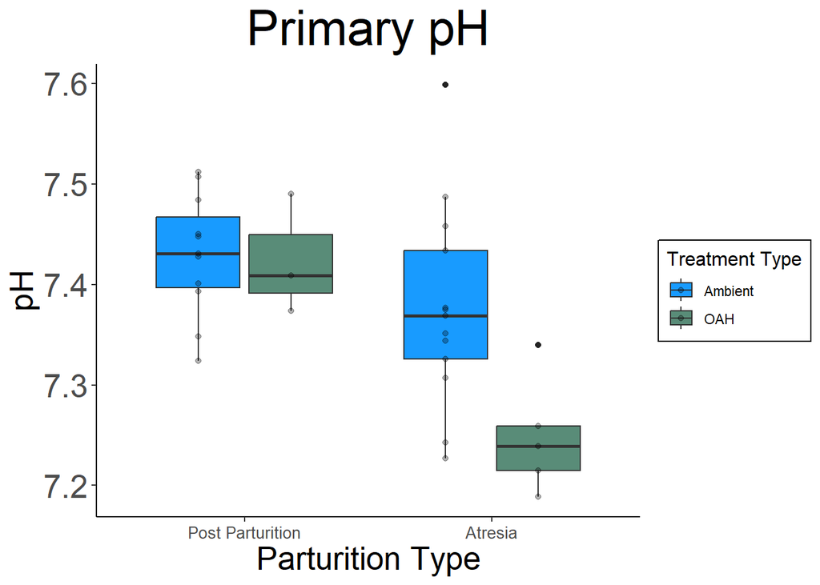

```r
# pH boxplot

# Primary samples
pH_primary_boxplot <- ggplot(data = Primary_Samples, aes(x = Pregnant.Or.Atresia, y = pH, fill = Ambient.Or.OAH)) +
  geom_boxplot(aes(x = Pregnant.Or.Atresia, y = pH, fill = Ambient.Or.OAH)) +
  geom_point(aes(color = Ambient.Or.OAH), position = position_dodge(width = 0.75), alpha = 0.3, color = "black") +
  labs(title = "Primary pH", x = "Parturition Type", y = "pH") +
  guides(fill = guide_legend((title = "Treatment Type"))) +
  scale_fill_manual(values = c("Ambient" = "#189bff", "OAH" = "#598c78")) +
  theme_classic() +
  theme(panel.background = element_rect(fill = "white"),
        plot.background = element_rect(fill = "white"),
        legend.background = element_rect(fill = "white", color = "black"),
        title = element_text(size = 12),
        plot.title = element_text(size = 30, hjust = 0.5),
        axis.text.x = element_text(size = 10),
        axis.text.y = element_text(size = 20),
        axis.title.x = element_text(size = 20),
        axis.title.y = element_text(size = 20))

print(pH_primary_boxplot)
```

```r
ggsave(filename = "data-images/pH_primary_boxplot.pdf", plot = pH_primary_boxplot, device = "pdf")
ggsave(filename = "data-images/pH_primary_boxplot.png", plot = pH_primary_boxplot, device = "png")
```

Ambient Samples

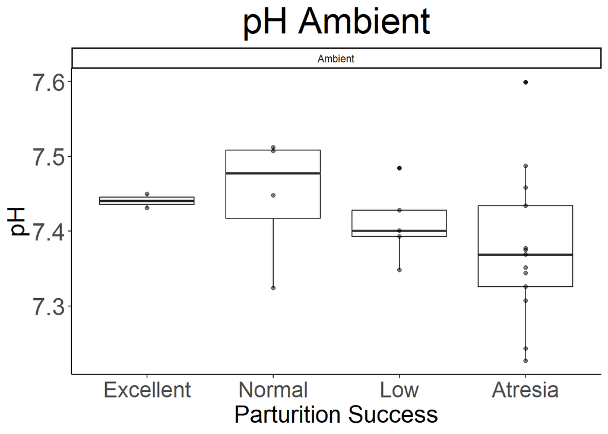

```r
# pH boxplot

# Ambient Samples
pH_ambient_boxplot <- ggplot(data = Ambient_Samples) +
  geom_boxplot(aes(x = Consensus_Brood_Condition, y = pH)) +
  geom_point(aes(x = Consensus_Brood_Condition, y = pH), alpha = 0.5, colour = "black") +
  labs(title = "pH Ambient", x = "Parturition Success", y = "pH") +
  facet_wrap(~ Ambient.Or.OAH) +
  theme_classic() +
  theme(panel.background = element_rect(fill = "white"),
        plot.background = element_rect(fill = "white"),
        legend.background = element_rect(fill = "white", color = "black"),
        title = element_text(size = 12),
        plot.title = element_text(size = 30, hjust = 0.5),
        axis.text.x = element_text(size = 18),
        axis.text.y = element_text(size = 20),
        axis.title.x = element_text(size = 20),
        axis.title.y = element_text(size = 20))

print(pH_ambient_boxplot)
```

```r
ggsave(filename = "data-images/pH_ambient_boxplot.pdf", plot = pH_ambient_boxplot, device = "pdf")
ggsave(filename = "data-images/pH_ambient_boxplot.png", plot = pH_ambient_boxplot, device = "png")
```

Fecundity Samples

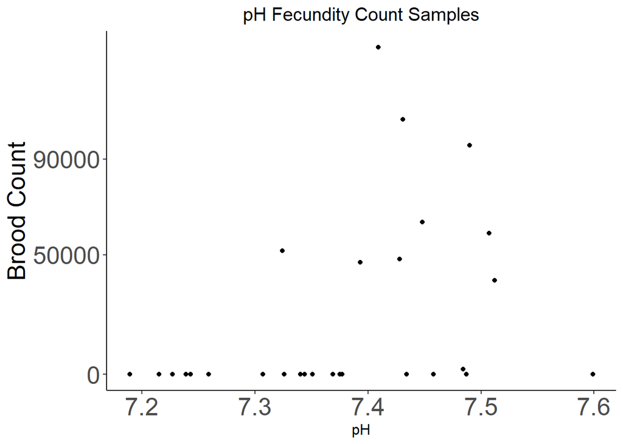

```r
# pH Scatterplot

# Fecundity Samples
pH_fecundity_count_scatterplot <- ggplot(data = Fecundity_Count_Samples) +
  geom_point(aes(x = pH, y = All_Fecundity), colour = "black") +
  labs(title = "pH Fecundity Count Samples", x = "pH", y = "Brood Count") +
  scale_y_continuous(breaks = c(0, 50000, 90000)) +
  theme_classic() +
  theme(panel.background = element_rect(fill = "white"),
        plot.background = element_rect(fill = "white"),
        legend.background = element_rect(fill = "white", color = "black"),
        plot.title = element_text(size = 15, hjust = 0.5),
        axis.text.x = element_text(size = 20),
        axis.text.y = element_text(size = 20),
        axis.title.x = element_text(size = 12),
        axis.title.y = element_text(size = 20))

print(pH_fecundity_count_scatterplot)
```

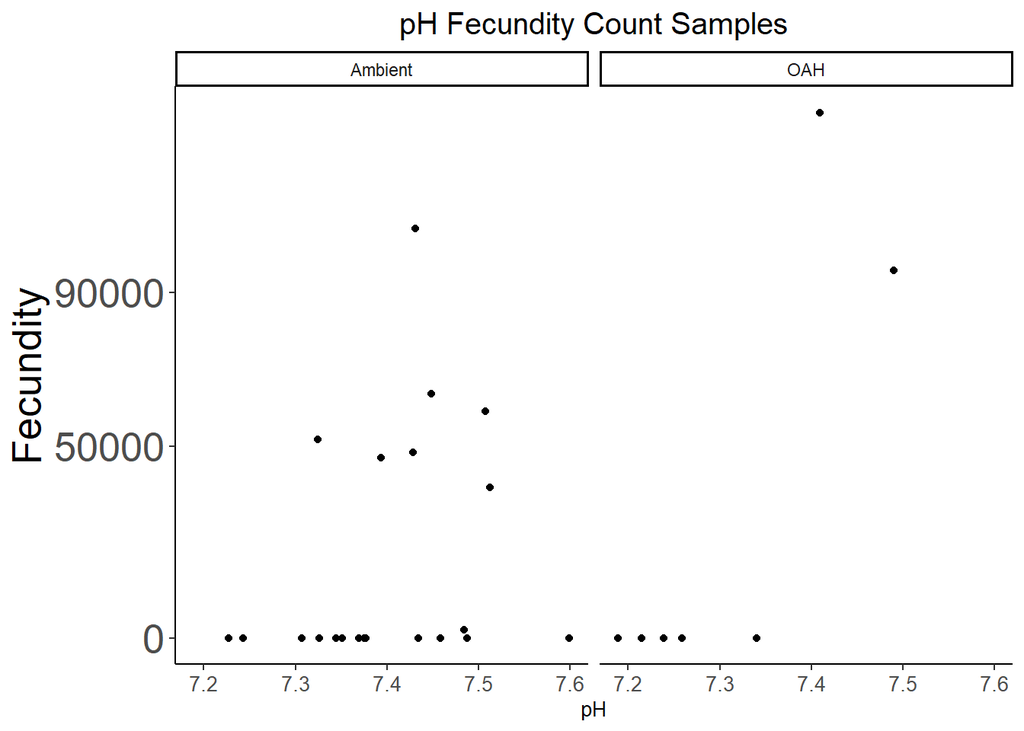

```r
ggsave(filename = "data-images/pH_fecundity_count_scatterplot.pdf", plot = pH_fecundity_count_scatterplot, device = "pdf")
ggsave(filename = "data-images/pH_fecundity_count_scatterplot.png", plot = pH_fecundity_count_scatterplot, device = "png")
# pH Fecundity Count facet scatterplot by Treatment
pH_fecundity_count_facet_scatterplot_treatment <- ggplot(data = Fecundity_Count_Samples) +
  geom_point(aes(x = pH, y = All_Fecundity), colour = "black") +
  labs(title = "pH Fecundity Count Samples", x = "pH", y = "Fecundity", ) +
  scale_y_continuous(breaks = c(0, 50000, 90000)) +
  facet_wrap(~ Ambient.Or.OAH) +
  theme_classic() +
  theme(panel.background = element_rect(fill = "white"),
        plot.background = element_rect(fill = "white"),
        legend.background = element_rect(fill = "white", color = "black"),
        plot.title = element_text(size = 15, hjust = 0.5),
        axis.text.x = element_text(size = 10),
        axis.text.y = element_text(size = 20),
        axis.title.x = element_text(size = 10),
        axis.title.y = element_text(size = 20))

print(pH_fecundity_count_facet_scatterplot_treatment)
```

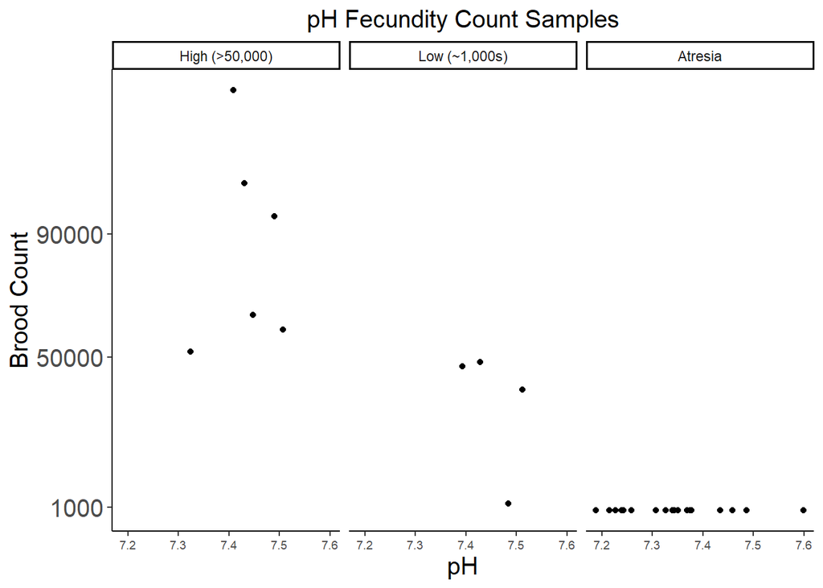

```r
# pH Fecundity Count facet scatterplot by Fecundity Class
pH_fecundity_count_facet_scatterplot_fecundity_class <- ggplot(data = Fecundity_Count_Samples) +
  geom_point(aes(x = pH, y = All_Fecundity), colour = "black") +
  labs(title = "pH Fecundity Count Samples", x = "pH", y = "Brood Count") +
  scale_y_continuous(breaks = c(1000, 50000, 90000)) +
  facet_wrap(~Fecundity_Class) +
  theme_classic() +
  theme(panel.background = element_rect(fill = "white"),
        plot.background = element_rect(fill = "white"),
        legend.background = element_rect(fill = "white", color = "black"),
        plot.title = element_text(size = 15, hjust = 0.5),
        axis.text.x = element_text(size = 7),
        axis.text.y = element_text(size = 15),
        axis.title.x = element_text(size = 15),
        axis.title.y = element_text(size = 15))


print(pH_fecundity_count_facet_scatterplot_fecundity_class)
```

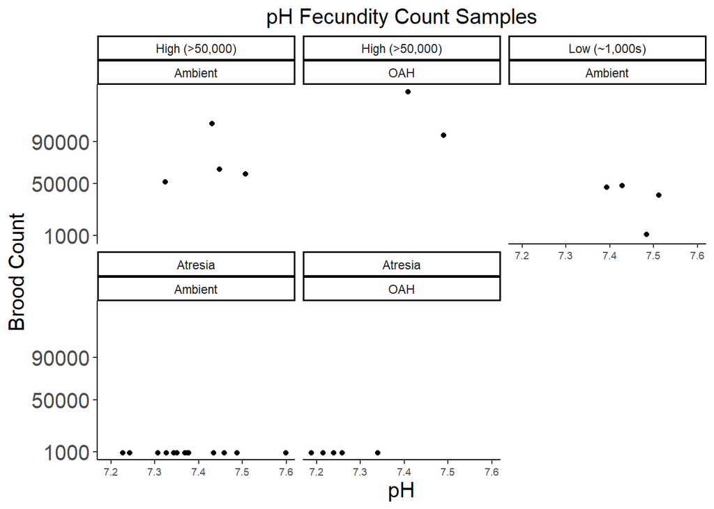

```r
pH_fecundity_count_facet_scatterplot_fecundity_class2 <- ggplot(data = Fecundity_Count_Samples) +
  geom_point(aes(x = pH, y = All_Fecundity), colour = "black") +
  labs(title = "pH Fecundity Count Samples", x = "pH", y = "Brood Count") +
  scale_y_continuous(breaks = c(1000, 50000, 90000)) +
  facet_wrap(Fecundity_Class ~ Ambient.Or.OAH) +
  theme_classic() +
  theme(panel.background = element_rect(fill = "white"),
        plot.background = element_rect(fill = "white"),
        legend.background = element_rect(fill = "white", color = "black"),
        plot.title = element_text(size = 15, hjust = 0.5),
        axis.text.x = element_text(size = 7),
        axis.text.y = element_text(size = 15),
        axis.title.x = element_text(size = 15),
        axis.title.y = element_text(size = 15))


print(pH_fecundity_count_facet_scatterplot_fecundity_class2)
```

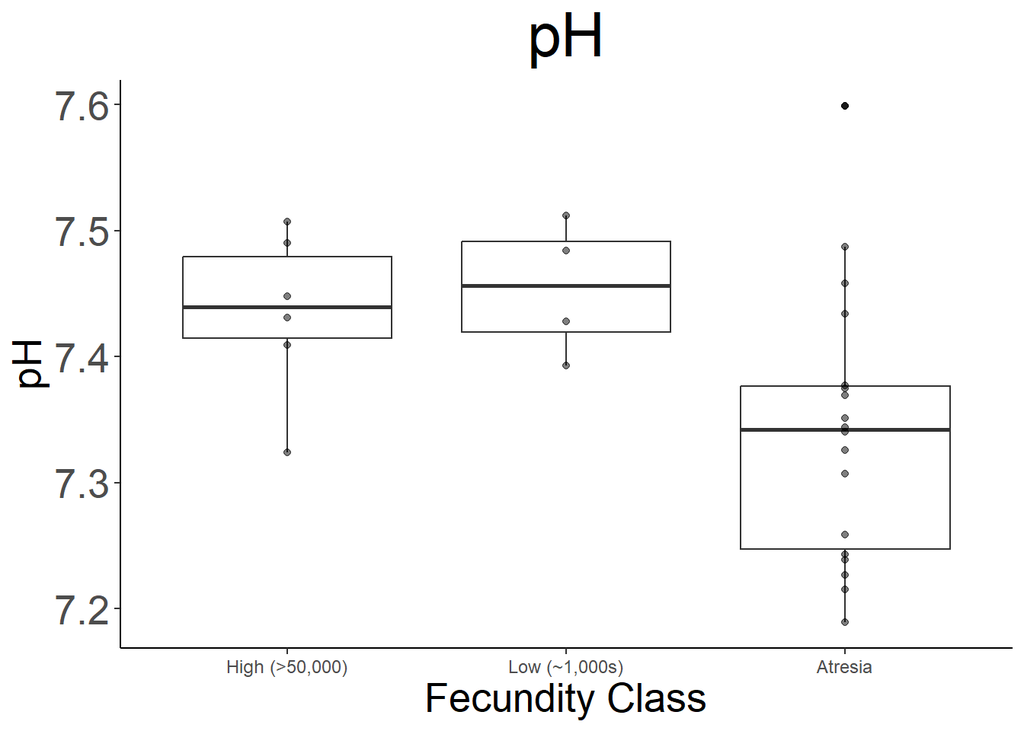

```r
# pH boxplot

# Fecundity Samples
pH_fecundity_boxplot <- ggplot(data = Fecundity_Samples) +
  geom_boxplot(aes(x = Fecundity_Class, y = pH)) +
  geom_point(aes(x = Fecundity_Class, y = pH), alpha = 0.5, colour = "black") +
  labs(title = "pH", x = "Fecundity Class", y = "pH") +
  theme_classic() +
  theme(panel.background = element_rect(fill = "white"),
        plot.background = element_rect(fill = "white"),
        legend.background = element_rect(fill = "white", color = "black"),
        title = element_text(size = 12),
        plot.title = element_text(size = 30, hjust = 0.5),
        axis.text.x = element_text(size = 9),
        axis.text.y = element_text(size = 20),
        axis.title.x = element_text(size = 20),
        axis.title.y = element_text(size = 20))

print(pH_fecundity_boxplot)
```

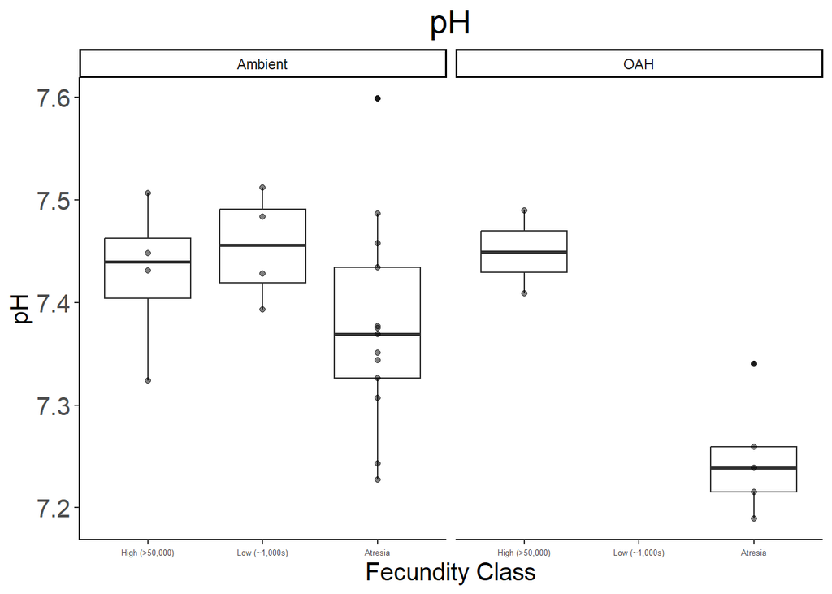

```r
ggsave(filename = "data-images/pH_fecundity_boxplot.pdf", plot = pH_fecundity_boxplot, device = "pdf")
ggsave(filename = "data-images/pH_fecundity_boxplot.png", plot = pH_fecundity_boxplot, device = "png")
# pH faceted boxplot
pH_fecundity_facet_boxplot <- ggplot(data = Fecundity_Samples) +
  geom_boxplot(aes(x = Fecundity_Class, y = pH)) +
  geom_point(aes(x = Fecundity_Class, y = pH), alpha = 0.5, colour = "black") +
  labs(title = "pH", x = "Fecundity Class", y = "pH") +
  facet_wrap(~ Ambient.Or.OAH) +
  theme_classic() +
  theme(panel.background = element_rect(fill = "white"),
        plot.background = element_rect(fill = "white"),
        legend.background = element_rect(fill = "white", color = "black"),
        title = element_text(size = 12),
        plot.title = element_text(size = 20, hjust = 0.5),
        axis.text.x = element_text(size = 5),
        axis.text.y = element_text(size = 15),
        axis.title.x = element_text(size = 15),
        axis.title.y = element_text(size = 15))

print(pH_fecundity_facet_boxplot)
```

```r
ggsave(filename = "data-images/pH_fecundity_facet_boxplot.pdf", plot = pH_fecundity_facet_boxplot, device = "pdf")
ggsave(filename = "data-images/pH_fecundity_facet_boxplot.png", plot = pH_fecundity_facet_boxplot, device = "png")
```

Ambient Fecundity Samples

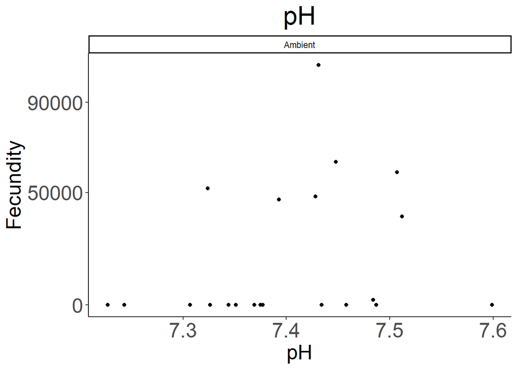

```r
# pH Scatterplot

# Amb_fec Samples:
# Note When using Fecundity_Or_Brood_Count col, the "No Parturition" aka atresia ids are automatically removed in plots, and results display numerical count, but this may cause issues if column is called in stat tests
# Refer to 'All_Fecundity' col (all numeric, includes atresia ids as 0)
# Refer to 'Fecundity_No_Atresia' col (all numeric, excludes atresia ids)
# Refer to 'Fecundity_Class' col for categorical classification of fecund data (Not 'Consensus_Fecundity' col, which is same, but raw data input)

# Amb Fec Count Samples : With atresia Ids
pH_amb_fec_all_scatterplot <- ggplot(data = Amb_Fec_Samples) +
  geom_point(aes(x = pH, y = All_Fecundity), colour = "black") +
  labs(title = "pH", x = "pH", y = "Fecundity") +
  scale_y_continuous(breaks = c(0, 50000, 90000)) +
  facet_wrap(~ Ambient.Or.OAH) +
  theme_classic() +
  theme(panel.background = element_rect(fill = "white"),
        plot.background = element_rect(fill = "white"),
        legend.background = element_rect(fill = "white", color = "black"),
        plot.title = element_text(size = 25, hjust = 0.5),
        axis.text.x = element_text(size = 20),
        axis.text.y = element_text(size = 20),
        axis.title.x = element_text(size = 20),
        axis.title.y = element_text(size = 20))

print(pH_amb_fec_all_scatterplot)
```

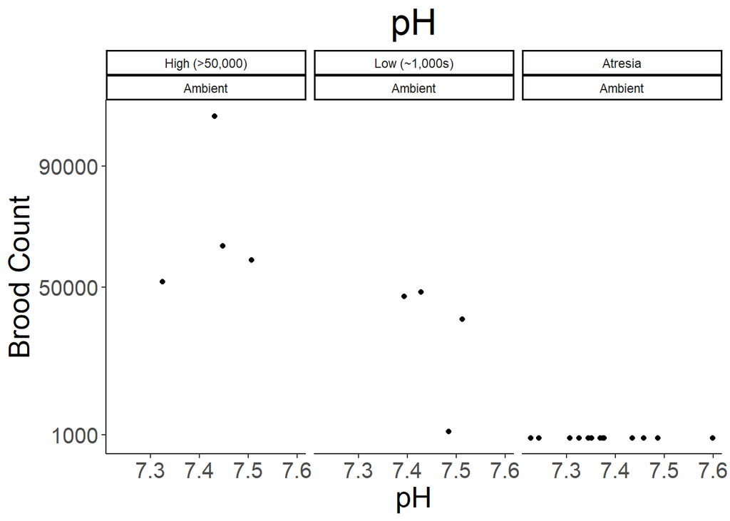

```r
ggsave(filename = "data-images/pH_amb_fec_all_scatterplot.pdf", plot = pH_amb_fec_all_scatterplot, device = "pdf")
ggsave(filename = "data-images/pH_amb_fec_all_scatterplot.png", plot = pH_amb_fec_all_scatterplot, device = "png")
# pH Amb Fec Count facet scatterplot by Fecundity Class
pH_amb_fec_all_facet_scatterplot_fecundity_class <- ggplot(data = Amb_Fec_Samples) +
  geom_point(aes(x = pH, y = All_Fecundity), colour = "black") +
  labs(title = "pH", x = "pH", y = "Brood Count") +
  scale_y_continuous(breaks = c(1000, 50000, 90000)) +
  facet_wrap(Fecundity_Class ~ Ambient.Or.OAH) +
  theme_classic() +
  theme(panel.background = element_rect(fill = "white"),
        plot.background = element_rect(fill = "white"),
        legend.background = element_rect(fill = "white", color = "black"),
        plot.title = element_text(size = 25, hjust = 0.5),
        axis.text.x = element_text(size = 15),
        axis.text.y = element_text(size = 15),
        axis.title.x = element_text(size = 20),
        axis.title.y = element_text(size = 20))

print(pH_amb_fec_all_facet_scatterplot_fecundity_class)
```

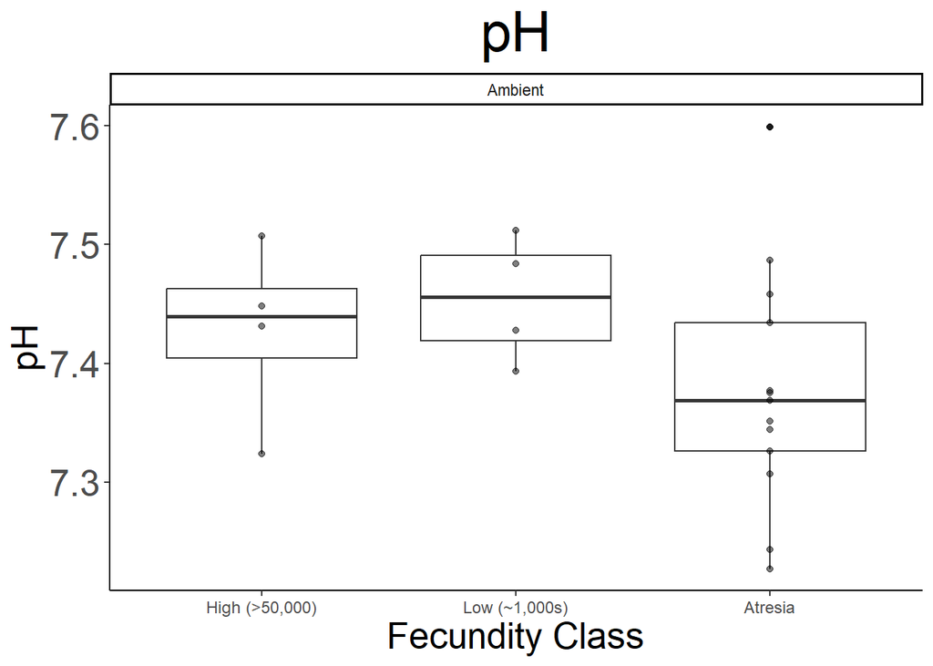

```r
# pH boxplot

# Amb_Fec Samples with Atresia Ids
pH_amb_fec_boxplot <- ggplot(data = Amb_Fec_Samples) +
  geom_boxplot(aes(x = Fecundity_Class, y = pH)) +
  geom_point(aes(x = Fecundity_Class, y = pH), alpha = 0.5, colour = "black") +
  labs(title = "pH", x = "Fecundity Class", y = "pH") +
   facet_wrap(~ Ambient.Or.OAH) +
  theme_classic() +
  theme(panel.background = element_rect(fill = "white"),
        plot.background = element_rect(fill = "white"),
        legend.background = element_rect(fill = "white", color = "black"),
        title = element_text(size = 12),
        plot.title = element_text(size = 30, hjust = 0.5),
        axis.text.x = element_text(size = 9),
        axis.text.y = element_text(size = 20),
        axis.title.x = element_text(size = 20),
        axis.title.y = element_text(size = 20))

print(pH_amb_fec_boxplot)
```

```r
ggsave(filename = "data-images/pH_amb_fec_boxplot.pdf", plot = pH_amb_fec_boxplot, device = "pdf")
ggsave(filename = "data-images/pH_amb_fec_boxplot.png", plot = pH_amb_fec_boxplot, device = "png")
```

# Hct : Hematocrit

Primary Samples

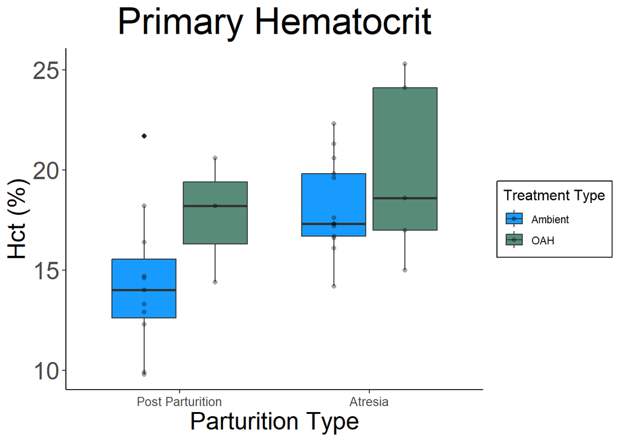

```r
# Primary Samples

# hematocrit boxplot: General Samples
hct_primary_boxplot <- ggplot(data = Primary_Samples, aes(x = Pregnant.Or.Atresia, y = Hct...., fill = Ambient.Or.OAH)) +
  geom_boxplot(aes(x = Pregnant.Or.Atresia, y = Hct...., fill = Ambient.Or.OAH)) +
  geom_point(aes(color = Ambient.Or.OAH), position = position_dodge(width = 0.75), alpha = 0.3, color = "black") +
  labs(title = "Primary Hematocrit", x = "Parturition Type", y = "Hct (%)") +
  guides(fill = guide_legend((title = "Treatment Type"))) +
  scale_fill_manual(values = c("Ambient" = "#189bff", "OAH" = "#598c78")) +
  theme_classic() +
  theme(panel.background = element_rect(fill = "white"),
        plot.background = element_rect(fill = "white"),
        legend.background = element_rect(fill = "white", color = "black"),
        title = element_text(size = 12),
        plot.title = element_text(size = 30, hjust = 0.5),
        axis.text.x = element_text(size = 10),
        axis.text.y = element_text(size = 20),
        axis.title.x = element_text(size = 20),
        axis.title.y = element_text(size = 20))

print(hct_primary_boxplot)
```

```r
ggsave(filename = "data-images/hct_primary_boxplot.pdf", plot = hct_primary_boxplot, device = "pdf")
ggsave(filename = "data-images/hct_primary_boxplot.png", plot = hct_primary_boxplot, device = "png")
```

Ambient Samples

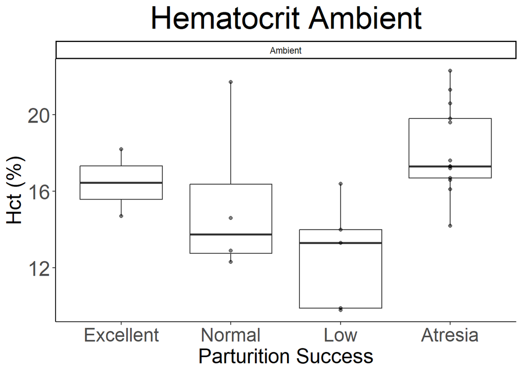

```r
# hct boxplot

# Ambient Samples
hct_ambient_boxplot <- ggplot(data = Ambient_Samples) +
  geom_boxplot(aes(x = Consensus_Brood_Condition, y = Hct....)) +
  geom_point(aes(x = Consensus_Brood_Condition, y = Hct....), alpha = 0.5, colour = "black") +
  labs(title = "Hematocrit Ambient", x = "Parturition Success", y = "Hct (%)") +
  facet_wrap(~ Ambient.Or.OAH) +
  theme_classic() +
  theme(panel.background = element_rect(fill = "white"),
        plot.background = element_rect(fill = "white"),
        legend.background = element_rect(fill = "white", color = "black"),
        title = element_text(size = 12),
        plot.title = element_text(size = 30, hjust = 0.5),
        axis.text.x = element_text(size = 18),
        axis.text.y = element_text(size = 20),
        axis.title.x = element_text(size = 20),
        axis.title.y = element_text(size = 20))

print(hct_ambient_boxplot)
```

```r
ggsave(filename = "data-images/hct_ambient_boxplot.pdf", plot = hct_ambient_boxplot, device = "pdf")
ggsave(filename = "data-images/hct_ambient_boxplot.png", plot = hct_ambient_boxplot, device = "png")
```

Fecundity Samples

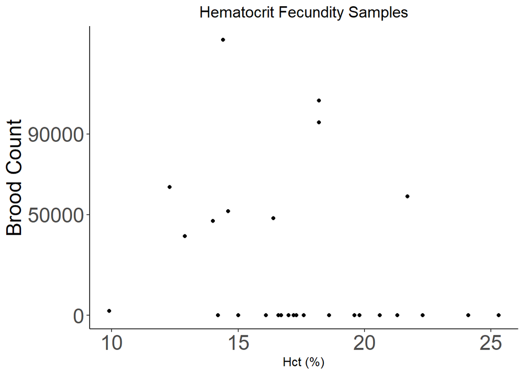

```r
# hct Scatterplot

# Fecundity Samples
hct_all_fecundity_scatterplot <- ggplot(data = Fecundity_Count_Samples) +
  geom_point(aes(x = Hct...., y = All_Fecundity), colour = "black") +
  labs(title = "Hematocrit Fecundity Samples", x = "Hct (%)", y = "Brood Count") +
  scale_y_continuous(breaks = c(0, 50000, 90000)) +
  theme_classic() +
  theme(panel.background = element_rect(fill = "white"),
        plot.background = element_rect(fill = "white"),
        legend.background = element_rect(fill = "white", color = "black"),
        plot.title = element_text(size = 15, hjust = 0.5),
        axis.text.x = element_text(size = 20),
        axis.text.y = element_text(size = 20),
        axis.title.x = element_text(size = 12),
        axis.title.y = element_text(size = 20))

print(hct_all_fecundity_scatterplot)
```

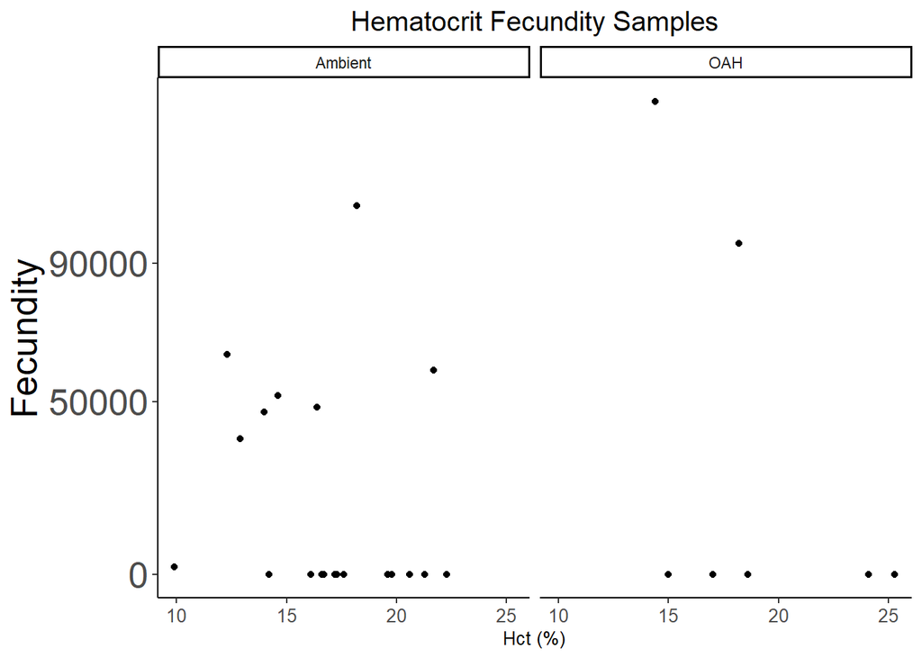

```r
ggsave(filename = "data-images/hct_all_fecundity_scatterplot.pdf", plot = hct_all_fecundity_scatterplot, device = "pdf")
ggsave(filename = "data-images/hct_all_fecundity_scatterplot.png", plot = hct_all_fecundity_scatterplot, device = "png")
# Hct Fecundity Count facet scatterplot by Treatment
hct_all_fecundity_count_facet_scatterplot_treatment <- ggplot(data = Fecundity_Samples) +
  geom_point(aes(x = Hct...., y = All_Fecundity), colour = "black") +
  labs(title = "Hematocrit Fecundity Samples", x = "Hct (%)", y = "Fecundity") +
  scale_y_continuous(breaks = c(0, 50000, 90000)) +
  facet_wrap(~ Ambient.Or.OAH) +
  theme_classic() +
  theme(panel.background = element_rect(fill = "white"),
        plot.background = element_rect(fill = "white"),
        legend.background = element_rect(fill = "white", color = "black"),
        plot.title = element_text(size = 15, hjust = 0.5),
        axis.text.x = element_text(size = 10),
        axis.text.y = element_text(size = 20),
        axis.title.x = element_text(size = 10),
        axis.title.y = element_text(size = 20))

print(hct_all_fecundity_count_facet_scatterplot_treatment)
```

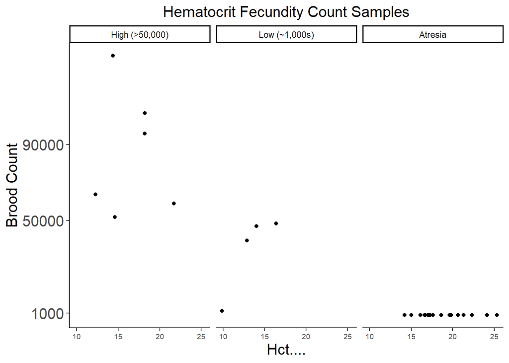

```r
# Hct fecundity count facet scatterplot by Fecundity Class
hct_fecundity_count_facet_scatterplot_fecundity_class <- ggplot(data = Fecundity_Samples) +
  geom_point(aes(x = Hct...., y = All_Fecundity), colour = "black") +
  labs(title = "Hematocrit Fecundity Count Samples", x = "Hct....", y = "Brood Count") +
  scale_y_continuous(breaks = c(1000, 50000, 90000)) +
  facet_wrap(~ Fecundity_Class) +
  theme_classic() +
  theme(panel.background = element_rect(fill = "white"),
        plot.background = element_rect(fill = "white"),
        legend.background = element_rect(fill = "white", color = "black"),
        plot.title = element_text(size = 15, hjust = 0.5),
        axis.text.x = element_text(size = 7),
        axis.text.y = element_text(size = 15),
        axis.title.x = element_text(size = 15),
        axis.title.y = element_text(size = 15))


print(hct_fecundity_count_facet_scatterplot_fecundity_class)
```

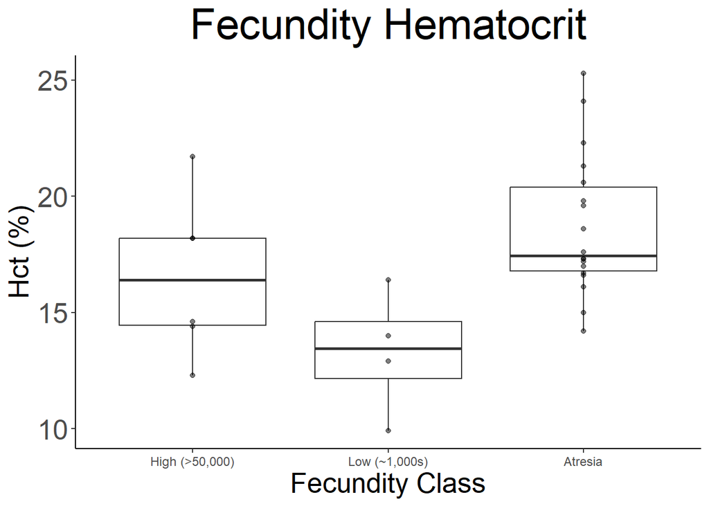

```r
# Hct boxplot

# Fecundity Samples
hct_fecundity_boxplot <- ggplot(data = Fecundity_Samples) +
  geom_boxplot(aes(x = Fecundity_Class, y = Hct....)) +
  geom_point(aes(x = Fecundity_Class, y = Hct....), alpha = 0.5, colour = "black") +
  labs(title = "Fecundity Hematocrit", x = "Fecundity Class", y = "Hct (%)") +
  theme_classic() +
  theme(panel.background = element_rect(fill = "white"),
        plot.background = element_rect(fill = "white"),
        legend.background = element_rect(fill = "white", color = "black"),
        plot.title = element_text(size = 30, hjust = 0.5),
        axis.text.x = element_text(size = 9),
        axis.text.y = element_text(size = 20),
        axis.title.x = element_text(size = 20),
        axis.title.y = element_text(size = 20))

print(hct_fecundity_boxplot)
```

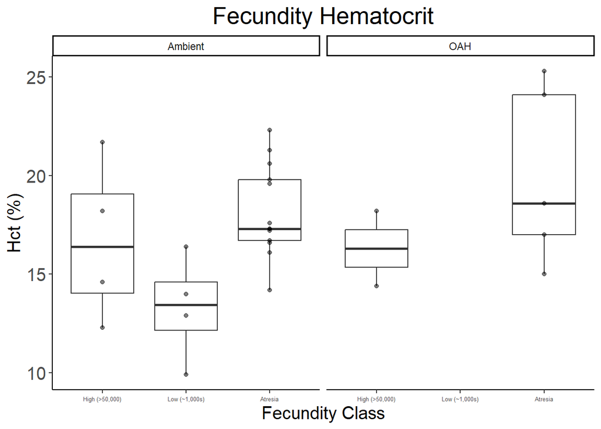

```r
ggsave(filename = "data-images/hct_fecundity_boxplot.pdf", plot = hct_fecundity_boxplot, device = "pdf")
ggsave(filename = "data-images/hct_fecundity_boxplot.png", plot = hct_fecundity_boxplot, device = "png")
# hct faceted boxplot
hct_fecundity_facet_boxplot <- ggplot(data = Fecundity_Samples) +
  geom_boxplot(aes(x = Fecundity_Class, y = Hct....)) +
  geom_point(aes(x = Fecundity_Class, y = Hct....), alpha = 0.5, colour = "black") +
  labs(title = "Fecundity Hematocrit", x = "Fecundity Class", y = "Hct (%)") +
  facet_wrap(~ Ambient.Or.OAH) +
  theme_classic() +
  theme(panel.background = element_rect(fill = "white"),
        plot.background = element_rect(fill = "white"),
        legend.background = element_rect(fill = "white", color = "black"),
        plot.title = element_text(size = 20, hjust = 0.5),
        axis.text.x = element_text(size = 5),
        axis.text.y = element_text(size = 15),
        axis.title.x = element_text(size = 15),
        axis.title.y = element_text(size = 15))

print(hct_fecundity_facet_boxplot)
```

```r
ggsave(filename = "data-images/hct_fecundity_facet_boxplot.pdf", plot = hct_fecundity_facet_boxplot, device = "pdf")
ggsave(filename = "data-images/hct_fecundity_facet_boxplot.png", plot = hct_fecundity_facet_boxplot, device = "png")
```

Ambient Fecundity Samples

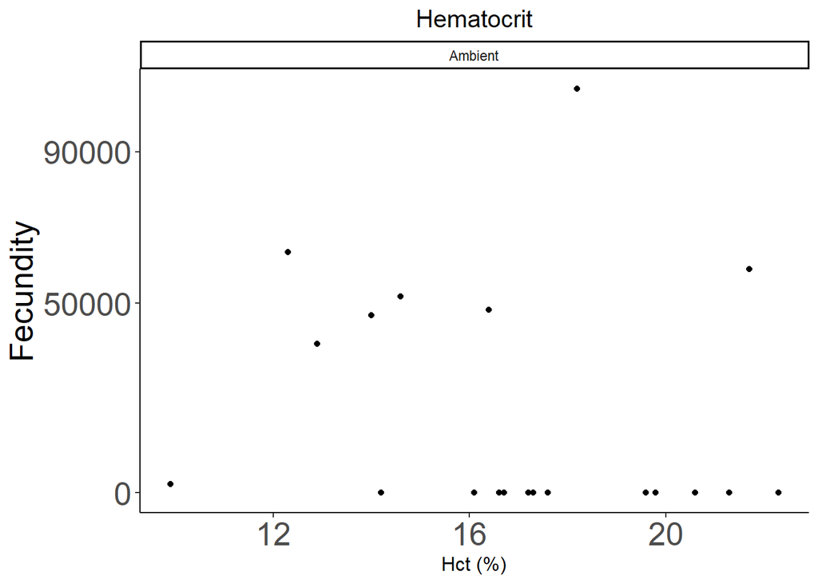

```r
# Hct Scatterplot

# Amb Fec Count Samples : With atresia Ids
hct_amb_fec_count_scatterplot <- ggplot(data = Amb_Fec_Samples) +
  geom_point(aes(x = Hct...., y = All_Fecundity), colour = "black") +
  labs(title = "Hematocrit", x = "Hct (%)", y = "Fecundity") +
  scale_y_continuous(breaks = c(0, 50000, 90000)) +
  facet_wrap(~ Ambient.Or.OAH) +
  theme_classic() +
  theme(panel.background = element_rect(fill = "white"),
        plot.background = element_rect(fill = "white"),
        legend.background = element_rect(fill = "white", color = "black"),
        plot.title = element_text(size = 15, hjust = 0.5),
        axis.text.x = element_text(size = 20),
        axis.text.y = element_text(size = 20),
        axis.title.x = element_text(size = 12),
        axis.title.y = element_text(size = 20))

print(hct_amb_fec_count_scatterplot)
```

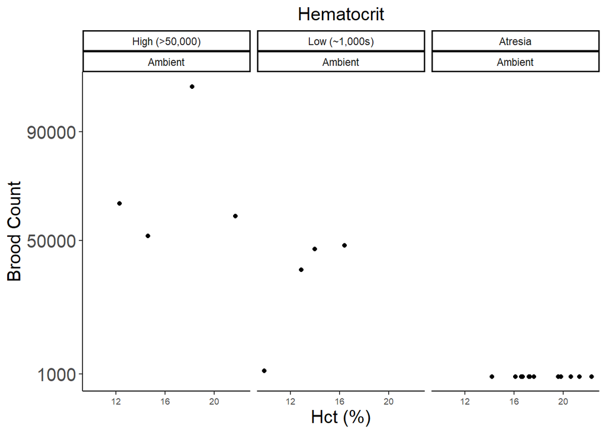

```r
ggsave(filename = "data-images/hct_amb_fec_count_scatterplot.pdf", plot = hct_amb_fec_count_scatterplot, device = "pdf")
ggsave(filename = "data-images/hct_amb_fec_count_scatterplot.png", plot = hct_amb_fec_count_scatterplot, device = "png")
# pH Amb Fec Count facet scatterplot by Fecundity Class
hct_amb_fec_count_facet_scatterplot_fecundity_class <- ggplot(data = Amb_Fec_Samples) +
  geom_point(aes(x = Hct...., y = All_Fecundity), colour = "black") +
  labs(title = "Hematocrit", x = "Hct (%)", y = "Brood Count") +
  scale_y_continuous(breaks = c(1000, 50000, 90000)) +
  facet_wrap(Fecundity_Class ~ Ambient.Or.OAH) +
  theme_classic() +
  theme(panel.background = element_rect(fill = "white"),
        plot.background = element_rect(fill = "white"),
        legend.background = element_rect(fill = "white", color = "black"),
        plot.title = element_text(size = 15, hjust = 0.5),
        axis.text.x = element_text(size = 7),
        axis.text.y = element_text(size = 15),
        axis.title.x = element_text(size = 15),
        axis.title.y = element_text(size = 15))

print(hct_amb_fec_count_facet_scatterplot_fecundity_class)
```

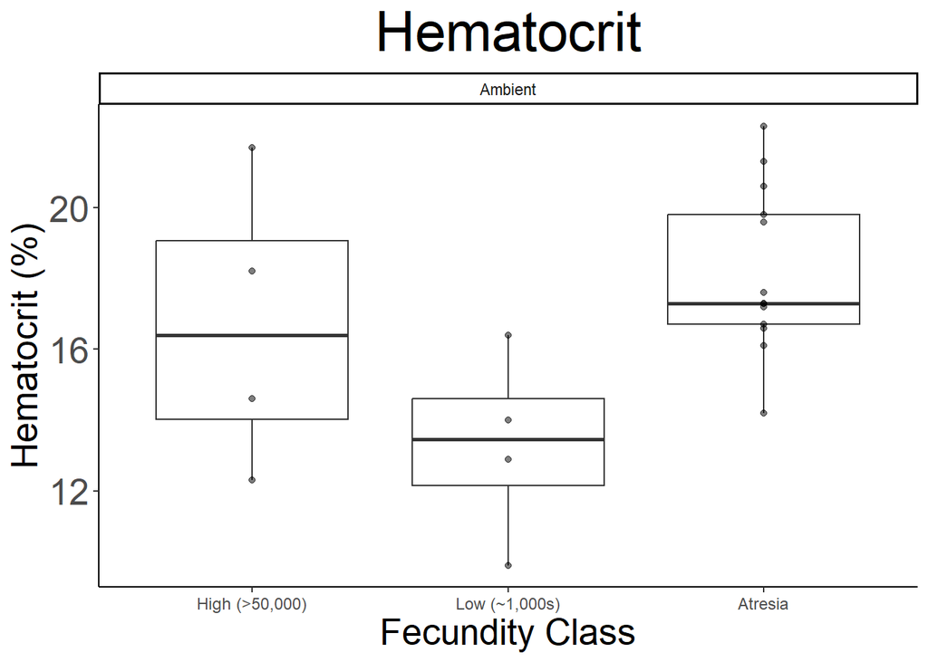

```r
# Hct boxplot

# Amb_Fec Samples with Atresia Ids
hct_amb_fec_boxplot <- ggplot(data = Amb_Fec_Samples) +
  geom_boxplot(aes(x = Fecundity_Class, y = Hct....)) +
  geom_point(aes(x = Fecundity_Class, y = Hct....), alpha = 0.5, colour = "black") +
  labs(title = "Hematocrit", x = "Fecundity Class", y = "Hematocrit (%)") +
   facet_wrap(~ Ambient.Or.OAH) +
  theme_classic() +
  theme(panel.background = element_rect(fill = "white"),
        plot.background = element_rect(fill = "white"),
        legend.background = element_rect(fill = "white", color = "black"),
        title = element_text(size = 12),
        plot.title = element_text(size = 30, hjust = 0.5),
        axis.text.x = element_text(size = 9),
        axis.text.y = element_text(size = 20),
        axis.title.x = element_text(size = 20),
        axis.title.y = element_text(size = 20))

print(hct_amb_fec_boxplot)
```

```r
ggsave(filename = "data-images/hct_amb_fec_boxplot.pdf", plot = hct_amb_fec_boxplot, device = "pdf")
ggsave(filename = "data-images/hct_amb_fec_boxplot.png", plot = hct_amb_fec_boxplot, device = "png")
```

# Glucose

Primary Samples

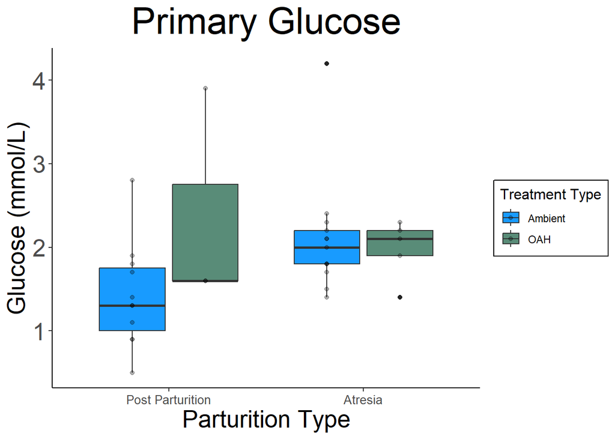

```r
# glucose boxplot

# Primary samples
glucose_primary_boxplot <- ggplot(data = Primary_Samples, aes(x = Pregnant.Or.Atresia, y = Glu..mmol.L., fill = Ambient.Or.OAH)) +
  geom_boxplot(aes(x = Pregnant.Or.Atresia, y = Glu..mmol.L., fill = Ambient.Or.OAH)) +
  geom_point(aes(color = Ambient.Or.OAH), position = position_dodge(width = 0.75), alpha = 0.3, color = "black") +
  labs(title = "Primary Glucose", x = "Parturition Type", y = "Glucose (mmol/L)") +
  guides(fill = guide_legend((title = "Treatment Type"))) +
  scale_fill_manual(values = c("Ambient" = "#189bff", "OAH" = "#598c78")) +
  theme_classic() +
  theme(panel.background = element_rect(fill = "white"),
        plot.background = element_rect(fill = "white"),
        legend.background = element_rect(fill = "white", color = "black"),
        title = element_text(size = 12),
        plot.title = element_text(size = 30, hjust = 0.5),
        axis.text.x = element_text(size = 10),
        axis.text.y = element_text(size = 20),
        axis.title.x = element_text(size = 20),
        axis.title.y = element_text(size = 20))

print(glucose_primary_boxplot)
```

```r
ggsave(filename = "data-images/glucose_primary_boxplot.pdf", plot = glucose_primary_boxplot, device = "pdf")
ggsave(filename = "data-images/glucose_primary_boxplot.png", plot = glucose_primary_boxplot, device = "png")
```

Ambient Samples

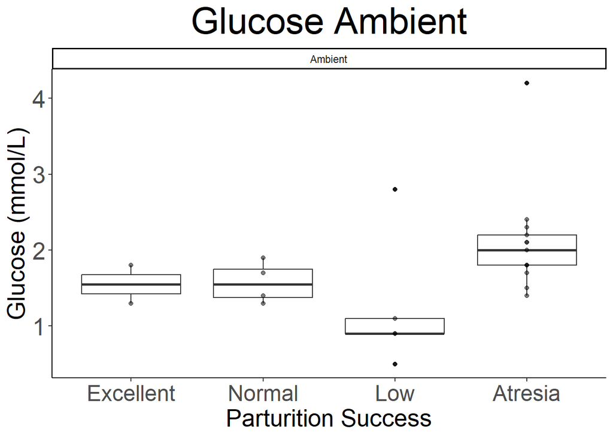

```r
# glucose boxplot

# Ambient Samples
glucose_ambient_boxplot <- ggplot(data = Ambient_Samples) +
  geom_boxplot(aes(x = Consensus_Brood_Condition, y = Glu..mmol.L.)) +
  geom_point(aes(x = Consensus_Brood_Condition, y = Glu..mmol.L.), alpha = 0.5, colour = "black") +
  labs(title = "Glucose Ambient", x = "Parturition Success", y = "Glucose (mmol/L)") +
  facet_wrap(~ Ambient.Or.OAH) +
  theme_classic() +
  theme(panel.background = element_rect(fill = "white"),
        plot.background = element_rect(fill = "white"),
        legend.background = element_rect(fill = "white", color = "black"),
        title = element_text(size = 12),
        plot.title = element_text(size = 30, hjust = 0.5),
        axis.text.x = element_text(size = 18),
        axis.text.y = element_text(size = 20),
        axis.title.x = element_text(size = 20),
        axis.title.y = element_text(size = 20))

print(glucose_ambient_boxplot)
```

```r
ggsave(filename = "data-images/glucose_ambient_boxplot.pdf", plot = glucose_ambient_boxplot, device = "pdf")
ggsave(filename = "data-images/glucose_ambient_boxplot.png", plot = glucose_ambient_boxplot, device = "png")
```

Fecundity Samples

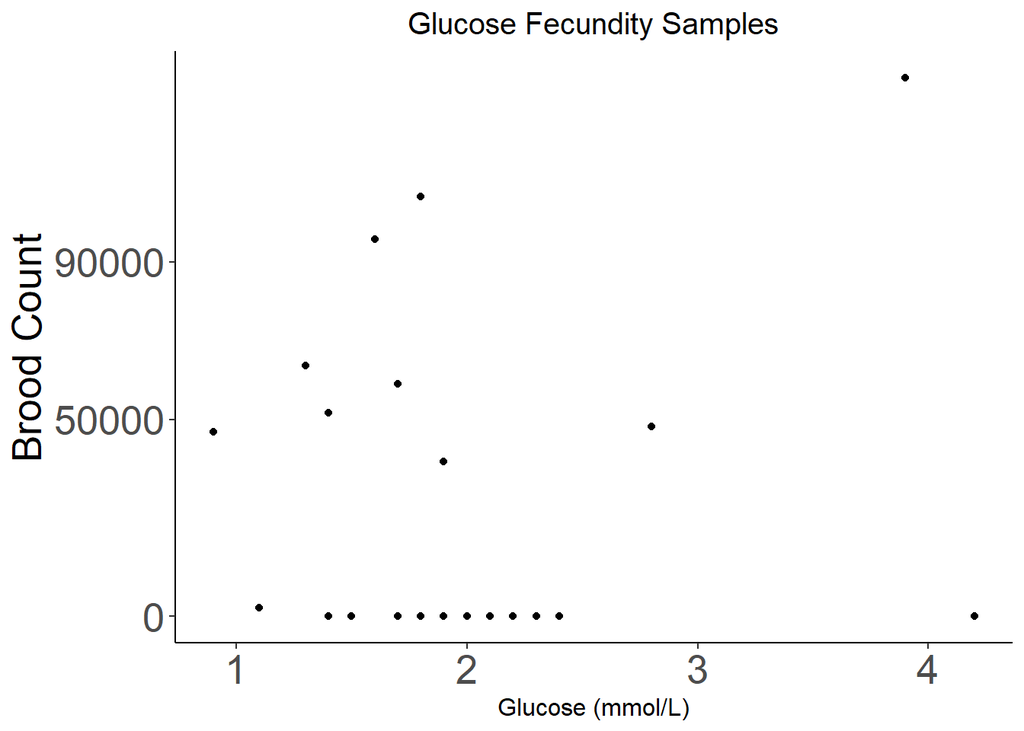

```r
# Glucose Scatterplot

# Fecundity Samples
glucose_all_fecundity_scatterplot <- ggplot(data = Fecundity_Samples) +
  geom_point(aes(x = Glu..mmol.L., y = All_Fecundity), colour = "black") +
  labs(title = "Glucose Fecundity Samples", x = "Glucose (mmol/L)", y = "Brood Count") +
  scale_y_continuous(breaks = c(0, 50000, 90000)) +
  theme_classic() +
  theme(panel.background = element_rect(fill = "white"),
        plot.background = element_rect(fill = "white"),
        legend.background = element_rect(fill = "white", color = "black"),
        plot.title = element_text(size = 15, hjust = 0.5),
        axis.text.x = element_text(size = 20),
        axis.text.y = element_text(size = 20),
        axis.title.x = element_text(size = 12),
        axis.title.y = element_text(size = 20))

print(glucose_all_fecundity_scatterplot)
```

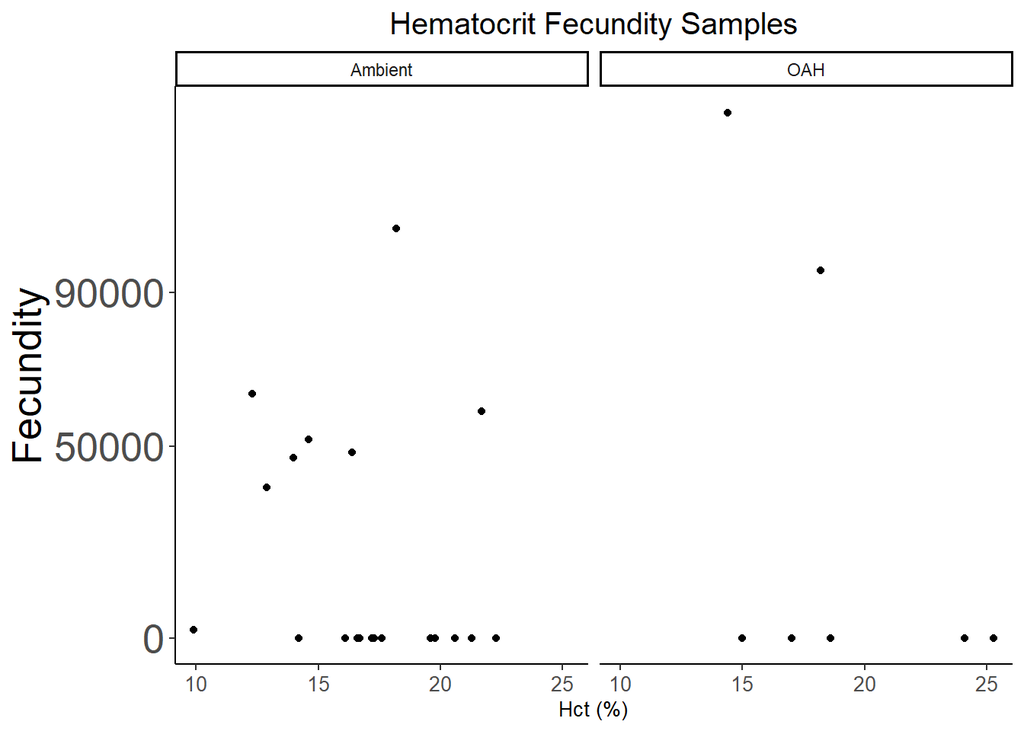

```r
ggsave(filename = "data-images/glucose_all_fecundity_scatterplot.pdf", plot = glucose_all_fecundity_scatterplot, device = "pdf")
ggsave(filename = "data-images/glucose_all_fecundity_scatterplot.png", plot = glucose_all_fecundity_scatterplot, device = "png")
# glucose Fecundity Count facet scatterplot by Treatment
glucose_all_fecundity_count_facet_scatterplot_treatment <- ggplot(data = Fecundity_Samples) +
  geom_point(aes(x = Glu..mmol.L., y = All_Fecundity), colour = "black") +
  labs(title = "Glucose Fecundity Samples", x = "Glucose (mmol/L)", y = "Fecundity") +
  scale_y_continuous(breaks = c(0, 50000, 90000)) +
  facet_wrap(~ Ambient.Or.OAH) +
  theme_classic() +
  theme(panel.background = element_rect(fill = "white"),
        plot.background = element_rect(fill = "white"),
        legend.background = element_rect(fill = "white", color = "black"),
        plot.title = element_text(size = 15, hjust = 0.5),
        axis.text.x = element_text(size = 10),
        axis.text.y = element_text(size = 20),
        axis.title.x = element_text(size = 10),
        axis.title.y = element_text(size = 20))

print(hct_all_fecundity_count_facet_scatterplot_treatment)
```

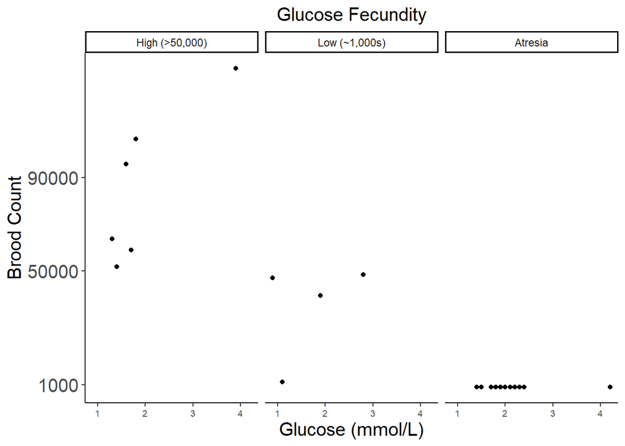

```r
# glucose fecundity count facet scatterplot by Fecundity Class
glucose_fecundity_count_facet_scatterplot_fecundity_class <- ggplot(data = Fecundity_Samples) +
  geom_point(aes(x = Glu..mmol.L., y = All_Fecundity), colour = "black") +
  labs(title = "Glucose Fecundity", x = "Glucose (mmol/L)", y = "Brood Count") +
  scale_y_continuous(breaks = c(1000, 50000, 90000)) +
  facet_wrap(~ Fecundity_Class) +
  theme_classic() +
  theme(panel.background = element_rect(fill = "white"),
        plot.background = element_rect(fill = "white"),
        legend.background = element_rect(fill = "white", color = "black"),
        plot.title = element_text(size = 15, hjust = 0.5),
        axis.text.x = element_text(size = 7),
        axis.text.y = element_text(size = 15),
        axis.title.x = element_text(size = 15),
        axis.title.y = element_text(size = 15))

print(glucose_fecundity_count_facet_scatterplot_fecundity_class)
```

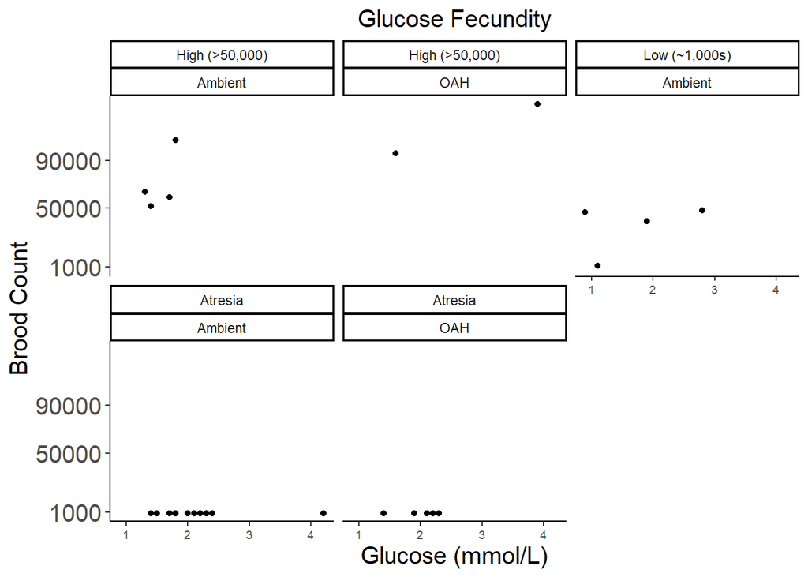

```r
glucose_fecundity_count_facet_scatterplot_fecundity_class2 <- ggplot(data = Fecundity_Samples) +
  geom_point(aes(x = Glu..mmol.L., y = All_Fecundity), colour = "black") +
  labs(title = "Glucose Fecundity", x = "Glucose (mmol/L)", y = "Brood Count") +
  scale_y_continuous(breaks = c(1000, 50000, 90000)) +
  facet_wrap(Fecundity_Class ~ Ambient.Or.OAH) +
  theme_classic() +
  theme(panel.background = element_rect(fill = "white"),
        plot.background = element_rect(fill = "white"),
        legend.background = element_rect(fill = "white", color = "black"),
        plot.title = element_text(size = 15, hjust = 0.5),
        axis.text.x = element_text(size = 7),
        axis.text.y = element_text(size = 15),
        axis.title.x = element_text(size = 15),
        axis.title.y = element_text(size = 15))

print(glucose_fecundity_count_facet_scatterplot_fecundity_class2)
```

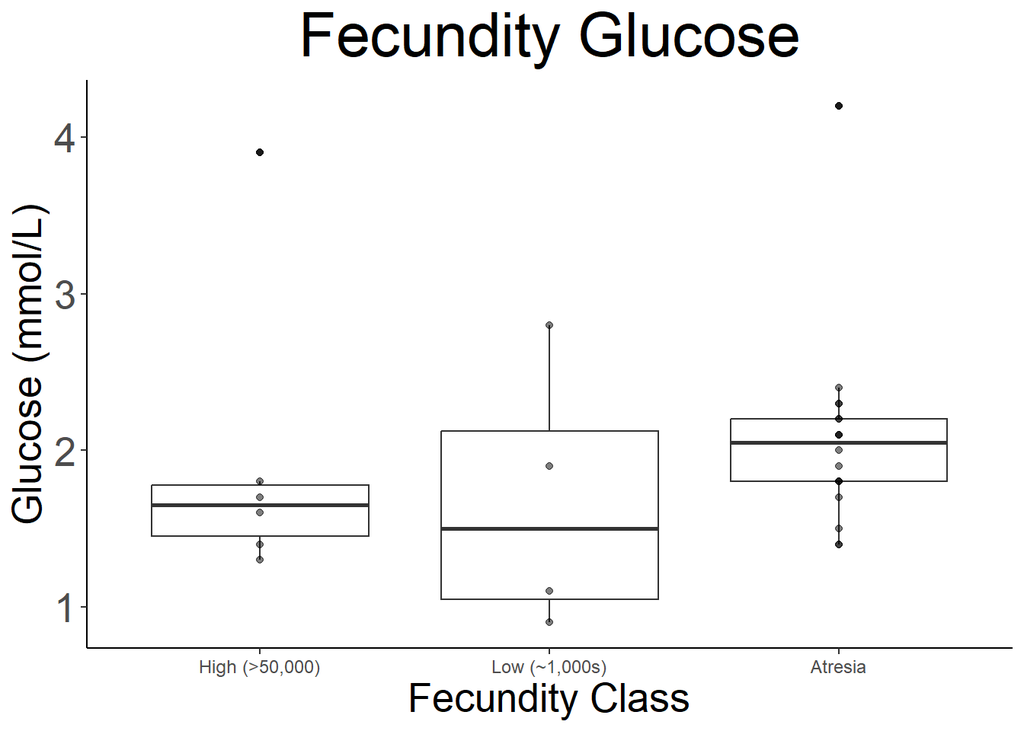

```r
# glucose boxplot

# Fecundity Samples
glucose_fecundity_boxplot <- ggplot(data = Fecundity_Samples) +
  geom_boxplot(aes(x = Fecundity_Class, y = Glu..mmol.L.)) +
  geom_point(aes(x = Fecundity_Class, y = Glu..mmol.L.), alpha = 0.5, colour = "black") +
  labs(title = "Fecundity Glucose", x = "Fecundity Class", y = "Glucose (mmol/L)") +
  theme_classic() +
  theme(panel.background = element_rect(fill = "white"),
        plot.background = element_rect(fill = "white"),
        legend.background = element_rect(fill = "white", color = "black"),
        plot.title = element_text(size = 30, hjust = 0.5),
        axis.text.x = element_text(size = 9),
        axis.text.y = element_text(size = 20),
        axis.title.x = element_text(size = 20),
        axis.title.y = element_text(size = 20))

print(glucose_fecundity_boxplot)
```

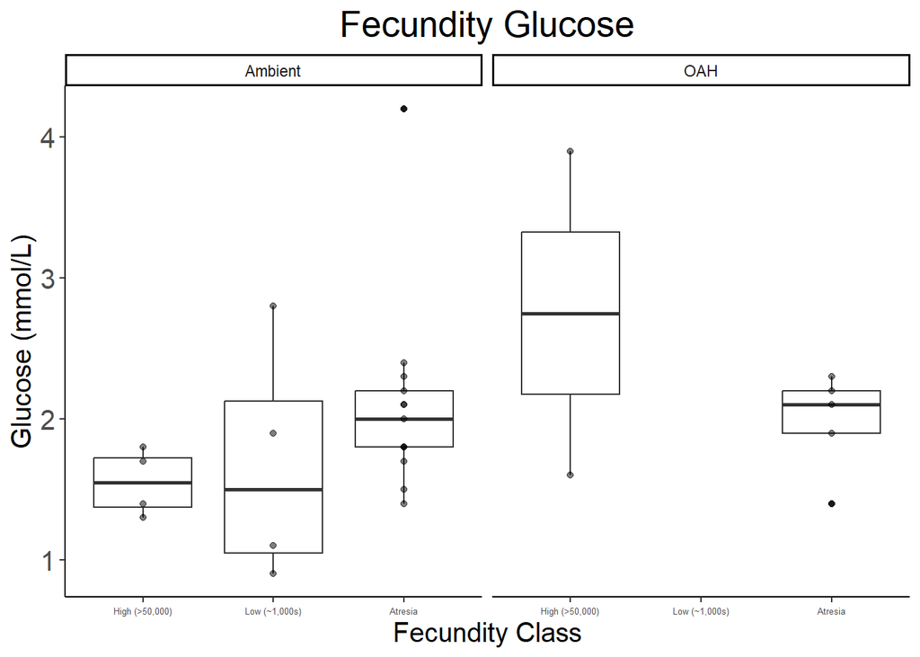

```r
ggsave(filename = "data-images/glucose_fecundity_boxplot.pdf", plot = glucose_fecundity_boxplot, device = "pdf")
ggsave(filename = "data-images/glucose_fecundity_boxplot.png", plot = glucose_fecundity_boxplot, device = "png")
# glucose fecundity faceted boxplot
glucose_fecundity_facet_boxplot <- ggplot(data = Fecundity_Samples) +
  geom_boxplot(aes(x = Fecundity_Class, y = Glu..mmol.L.)) +
  geom_point(aes(x = Fecundity_Class, y = Glu..mmol.L.), alpha = 0.5, colour = "black") +
  labs(title = "Fecundity Glucose", x = "Fecundity Class", y = "Glucose (mmol/L)") +
  facet_wrap(~ Ambient.Or.OAH) +
  theme_classic() +
  theme(panel.background = element_rect(fill = "white"),
        plot.background = element_rect(fill = "white"),
        legend.background = element_rect(fill = "white", color = "black"),
        plot.title = element_text(size = 20, hjust = 0.5),
        axis.text.x = element_text(size = 5),
        axis.text.y = element_text(size = 15),
        axis.title.x = element_text(size = 15),
        axis.title.y = element_text(size = 15))

print(glucose_fecundity_facet_boxplot)
```

```r
ggsave(filename = "data-images/glucose_fecundity_facet_boxplot.pdf", plot = glucose_fecundity_facet_boxplot, device = "pdf")
ggsave(filename = "data-images/glucose_fecundity_facet_boxplot.png", plot = glucose_fecundity_facet_boxplot, device = "png")
```

Ambient Fecundity Samples

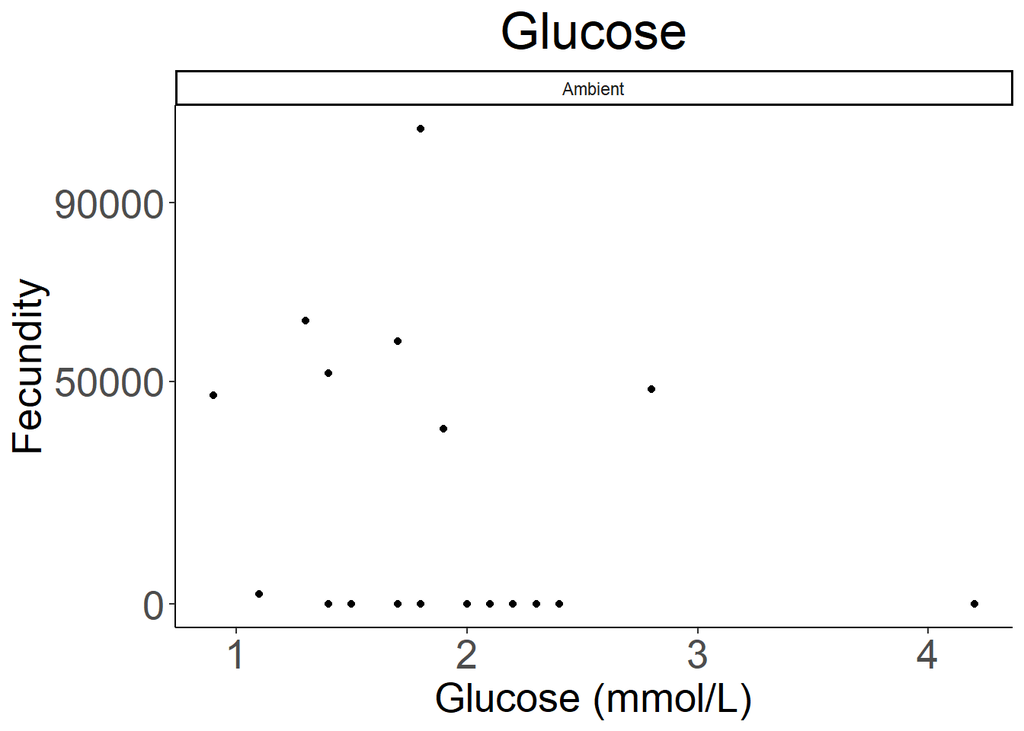

```r
# Glucose Scatterplot

# Amb_fec Samples:
# Note When using Fecundity_Or_Brood_Count col, the "No Parturition" aka atresia ids are automatically removed in plots, and results display numerical count, but this may cause issues if column is called in stat tests
# Refer to 'All_Fecundity' col (all numeric, includes atresia ids as 0)
# Refer to 'Fecundity_No_Atresia' col (all numeric, excludes atresia ids)
# Refer to 'Fecundity_Class' col for categorical classification of fecund data (Not 'Consensus_Fecundity' col, which is same, but raw data input)

# Amb Fec Count Samples : With atresia Ids
glucose_amb_fec_all_scatterplot <- ggplot(data = Amb_Fec_Samples) +
  geom_point(aes(x = Glu..mmol.L., y = All_Fecundity), colour = "black") +
  labs(title = "Glucose", x = "Glucose (mmol/L)", y = "Fecundity") +
  scale_y_continuous(breaks = c(0, 50000, 90000)) +
  facet_wrap(~ Ambient.Or.OAH) +
  theme_classic() +
  theme(panel.background = element_rect(fill = "white"),
        plot.background = element_rect(fill = "white"),
        legend.background = element_rect(fill = "white", color = "black"),
        plot.title = element_text(size = 25, hjust = 0.5),
        axis.text.x = element_text(size = 20),
        axis.text.y = element_text(size = 20),
        axis.title.x = element_text(size = 20),
        axis.title.y = element_text(size = 20))

print(glucose_amb_fec_all_scatterplot)
```

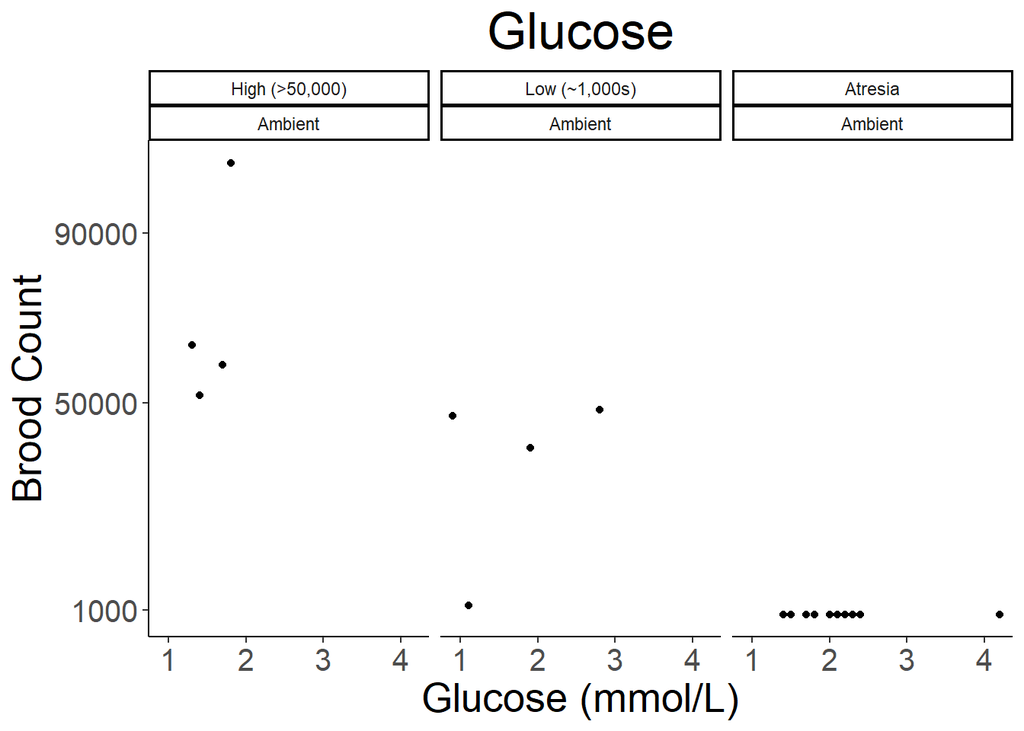

```r
ggsave(filename = "data-images/glucose_amb_fec_all_scatterplot.pdf", plot = glucose_amb_fec_all_scatterplot, device = "pdf")
ggsave(filename = "data-images/glucose_amb_fec_all_scatterplot.png", plot = glucose_amb_fec_all_scatterplot, device = "png")
# pH Amb Fec Count facet scatterplot by Fecundity Class
glucose_amb_fec_all_facet_scatterplot_fecundity_class <- ggplot(data = Amb_Fec_Samples) +
  geom_point(aes(x = Glu..mmol.L., y = All_Fecundity), colour = "black") +
  labs(title = "Glucose", x = "Glucose (mmol/L)", y = "Brood Count") +
  scale_y_continuous(breaks = c(1000, 50000, 90000)) +
  facet_wrap(Fecundity_Class ~ Ambient.Or.OAH) +
  theme_classic() +
  theme(panel.background = element_rect(fill = "white"),
        plot.background = element_rect(fill = "white"),
        legend.background = element_rect(fill = "white", color = "black"),
        plot.title = element_text(size = 25, hjust = 0.5),
        axis.text.x = element_text(size = 15),
        axis.text.y = element_text(size = 15),
        axis.title.x = element_text(size = 20),
        axis.title.y = element_text(size = 20))

print(glucose_amb_fec_all_facet_scatterplot_fecundity_class)
```